# R Notebook

Importing Libraries

```r
options(scipen = 99)
library(ggplot2)
library(GGally)
library(rsample)
library(caTools)
library(reshape2)
library(ggpubr)
library(corrplot)
library(psych)
library(ggpubr)
library(ggcorrplot)
library(pROC)
library(caret)
library(rpart)
library(rpart.plot)
library(plotrix)
library(e1071)
library(randomForest)
```

Creating new dataset

```r
df = adult
```

summarizing data what we are working with

```r
summary(df)
```

```
      age         workclass             fnlwgt         education         education.num   marital.status      occupation        relationship           race
 Min.   :17.00   Length:32561       Min.   :  12285   Length:32561       Min.   : 1.00   Length:32561       Length:32561       Length:32561       Length:32561
 1st Qu.:28.00   Class :character   1st Qu.: 117827   Class :character   1st Qu.: 9.00   Class :character   Class :character   Class :character   Class :character
 Median :37.00   Mode  :character   Median : 178356   Mode  :character   Median :10.00   Mode  :character   Mode  :character   Mode  :character   Mode  :character
 Mean   :38.58                      Mean   : 189778                      Mean   :10.08
 3rd Qu.:48.00                      3rd Qu.: 237051                      3rd Qu.:12.00
 Max.   :90.00                      Max.   :1484705                      Max.   :16.00
     sex             capital.gain    capital.loss    hours.per.week  native.country        income
 Length:32561       Min.   :    0   Min.   :   0.0   Min.   : 1.00   Length:32561       Length:32561
 Class :character   1st Qu.:    0   1st Qu.:   0.0   1st Qu.:40.00   Class :character   Class :character
 Mode  :character   Median :    0   Median :   0.0   Median :40.00   Mode  :character   Mode  :character
                    Mean   : 1078   Mean   :  87.3   Mean   :40.44
                    3rd Qu.:    0   3rd Qu.:   0.0   3rd Qu.:45.00
                    Max.   :99999   Max.   :4356.0   Max.   :99.00
```

checking if any column is NA

```r
colSums(is.na(df))
```

```
           age      workclass         fnlwgt      education  education.num marital.status     occupation   relationship           race            sex   capital.gain
             0              0              0              0              0              0              0              0              0              0              0
  capital.loss hours.per.week native.country         income
             0              0              0              0
```

There’s a problem in our data. Na values are marked as “?”. So we have to fix that first by converting “?” to NA values

```r
df[df == "?"] = NA
```

Now its showing our NA values

```r
colSums(is.na(df))
```

```
           age      workclass         fnlwgt      education  education.num marital.status     occupation   relationship           race            sex   capital.gain
             0           1836              0              0              0              0           1843              0              0              0              0
  capital.loss hours.per.week native.country         income
             0              0            583              0
```

Every column that has NA values is char type. So even if we fill that values it would be miss leading rather than its better to delete that rows.

```r
df = na.omit(df)
```

```r
summary(df)
```

```
      age         workclass             fnlwgt         education         education.num   marital.status      occupation        relationship           race
 Min.   :17.00   Length:30162       Min.   :  13769   Length:30162       Min.   : 1.00   Length:30162       Length:30162       Length:30162       Length:30162
 1st Qu.:28.00   Class :character   1st Qu.: 117627   Class :character   1st Qu.: 9.00   Class :character   Class :character   Class :character   Class :character
 Median :37.00   Mode  :character   Median : 178425   Mode  :character   Median :10.00   Mode  :character   Mode  :character   Mode  :character   Mode  :character
 Mean   :38.44                      Mean   : 189794                      Mean   :10.12
 3rd Qu.:47.00                      3rd Qu.: 237629                      3rd Qu.:13.00
 Max.   :90.00                      Max.   :1484705                      Max.   :16.00
     sex             capital.gain    capital.loss     hours.per.week  native.country        income
 Length:30162       Min.   :    0   Min.   :   0.00   Min.   : 1.00   Length:30162       Length:30162
 Class :character   1st Qu.:    0   1st Qu.:   0.00   1st Qu.:40.00   Class :character   Class :character
 Mode  :character   Median :    0   Median :   0.00   Median :40.00   Mode  :character   Mode  :character
                    Mean   : 1092   Mean   :  88.37   Mean   :40.93
                    3rd Qu.:    0   3rd Qu.:   0.00   3rd Qu.:45.00
                    Max.   :99999   Max.   :4356.00   Max.   :99.00
```

Plotting correlation for numeric columns

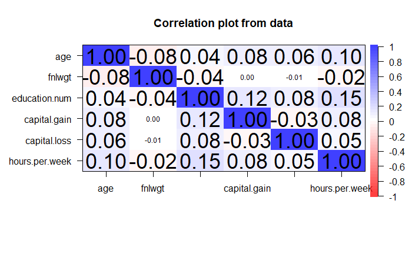

```
$corr
                       age        fnlwgt education.num  capital.gain capital.loss hours.per.week
age             1.00000000 -0.0765108361    0.04352609  0.0801542263  0.060165480     0.10159876
fnlwgt         -0.07651084  1.0000000000   -0.04499174  0.0004215674 -0.009749528    -0.02288575
education.num   0.04352609 -0.0449917421    1.00000000  0.1244159953  0.079646410     0.15252207
capital.gain    0.08015423  0.0004215674    0.12441600  1.0000000000 -0.032229327     0.08043180
capital.loss    0.06016548 -0.0097495278    0.07964641 -0.0322293265  1.000000000     0.05241705
hours.per.week  0.10159876 -0.0228857516    0.15252207  0.0804318007  0.052417049     1.00000000

$corrPos
```

| xName | yName | x | y | corr |
| --- | --- | --- | --- | --- |
| age | age | 1 | 6 | 1.0000000000 |
| fnlwgt | age | 2 | 6 | -0.0765108361 |
| fnlwgt | fnlwgt | 2 | 5 | 1.0000000000 |
| education.num | age | 3 | 6 | 0.0435260866 |
| education.num | fnlwgt | 3 | 5 | -0.0449917421 |
| education.num | education.num | 3 | 4 | 1.0000000000 |
| capital.gain | age | 4 | 6 | 0.0801542263 |
| capital.gain | fnlwgt | 4 | 5 | 0.0004215674 |
| capital.gain | education.num | 4 | 4 | 0.1244159953 |
| capital.gain | capital.gain | 4 | 3 | 1.0000000000 |

[output cut: 11 more lines]

```
$arg
$arg$type
[1] "upper"
```

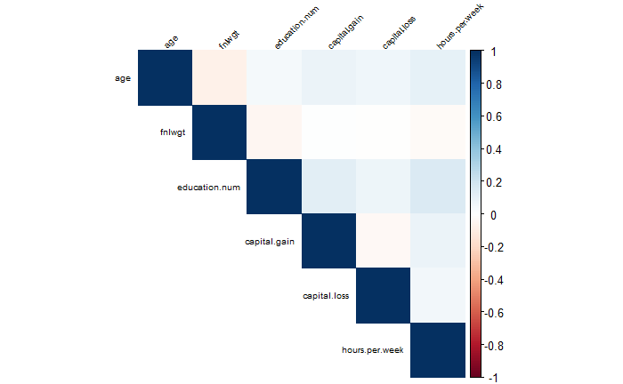

```r
correlation_plot(df)
```

Checking unique values to make it categorical

```r
cat("Unique values in Workclass:\n\n")
```

```
Unique values in Workclass:
```

```r
unique(df$workclass)
```

```
[1] "Private"          "State-gov"        "Federal-gov"      "Self-emp-not-inc" "Self-emp-inc"     "Local-gov"        "Without-pay"
```

```r
cat('\n')
```

```r
cat("Unique values in Education:\n\n")
```

```
Unique values in Education:
```

```r
unique(df$education)
```

```
 [1] "HS-grad"      "7th-8th"      "Some-college" "10th"         "Doctorate"    "Prof-school"  "Bachelors"    "Masters"      "11th"         "Assoc-voc"
[11] "1st-4th"      "5th-6th"      "Assoc-acdm"   "12th"         "9th"          "Preschool"
```

```r
cat('\n')
```

```r
cat("Unique values in Marital Status:\n\n")
```

```
Unique values in Marital Status:
```

```r
unique(df$marital.status)
```

```
[1] "Widowed"               "Divorced"              "Separated"             "Never-married"         "Married-civ-spouse"    "Married-spouse-absent"
[7] "Married-AF-spouse"
```

```r
cat('\n')
```

```r
cat("Unique values in Occupation:\n\n")
```

```
Unique values in Occupation:
```

```r
unique(df$occupation)
```

```
 [1] "Exec-managerial"   "Machine-op-inspct" "Prof-specialty"    "Other-service"     "Adm-clerical"      "Transport-moving"  "Sales"             "Craft-repair"
 [9] "Farming-fishing"   "Tech-support"      "Protective-serv"   "Handlers-cleaners" "Armed-Forces"      "Priv-house-serv"
```

```r
cat('\n')
```

```r
cat("Unique values in Relationship Status:\n\n")
```

```
Unique values in Relationship Status:
```

```r
unique(df$relationship)
```

```
[1] "Not-in-family"  "Unmarried"      "Own-child"      "Other-relative" "Husband"        "Wife"
```

```r
cat('\n')
```

```r
cat("Unique values in Race:\n\n")
```

```
Unique values in Race:
```

```r
unique(df$race)
```

```
[1] "White"              "Black"              "Asian-Pac-Islander" "Other"              "Amer-Indian-Eskimo"
```

```r
cat('\n')
```

```r
cat("Unique values in Native Country:\n\n")
```

```
Unique values in Native Country:
```

```r
unique(df$native.country)
```

```
 [1] "United-States"              "Mexico"                     "Greece"                     "Vietnam"                    "China"
 [6] "Taiwan"                     "India"                      "Philippines"                "Trinadad&Tobago"            "Canada"
[11] "South"                      "Holand-Netherlands"         "Puerto-Rico"                "Poland"                     "Iran"
[16] "England"                    "Germany"                    "Italy"                      "Japan"                      "Hong"
[21] "Honduras"                   "Cuba"                       "Ireland"                    "Cambodia"                   "Peru"
[26] "Nicaragua"                  "Dominican-Republic"         "Haiti"                      "Hungary"                    "Columbia"
[31] "Guatemala"                  "El-Salvador"                "Jamaica"                    "Ecuador"                    "France"
[36] "Yugoslavia"                 "Portugal"                   "Laos"                       "Thailand"                   "Outlying-US(Guam-USVI-etc)"
[41] "Scotland"
```

```r
cat('\n')
```

```r
cat("Unique values in Income:\n")
```

```
Unique values in Income:
```

```r
unique(df$income)
```

```
[1] "<=50K" ">50K"
```

Converting every possible columns to categorical data such as:

Workclass:

Private = 1 State-gov,Federal-gov,Local-gov = 2 Self_employed = 3 without-pay = 4

Education:

Hs-grad,Bachelors,prof-school = 1 MAsters = 2 Doctorate = 3 Rest = 4

Marital Status:

widowed, Divorced, Never-married, separated = 1 (not married) married-civ-spouse, married-AF-spouse,Married-spouse-absent = 2 (married)

Relationship status:

Deleting this columns

Race:

Native Country:

united States,canada,mexico,Trinad&Tobago,South, Puerto-rico,Hondurras, Cuba,Nicaragua, Dominican-Republic,Guatemala,EL-Salvador,Jamaica, Ecuador, Outlying-Us, Columbia, Ecuador, = 1 (America)

Greece, Holad-netherlands, Poland, England, Germany, Italy,Ireland, Hungary, France, Yugoslavia, Portugal, Scotland =2 (Europe)

Vietnam,China, India, Taiwan, Philippines,Iran, Japan, Hong,Cambodia,Laos, Thailand = 3 (asia)

Sex: Male = 1 Female = 2

Income:

# <=50K = 1 (less than 50k)

# >50K = 2 (more than 50 K)

```r
# Replace 'workclass' values in the existing dataframe
df$workclass <- ifelse(df$workclass == "Private", 1,
                       ifelse(df$workclass %in% c("State-gov", "Federal-gov", "Local-gov"), 2,
                       ifelse(df$workclass == "Without-pay", 4, 3)))

df$education <- ifelse(df$education %in% c("HS-grad", "Bachelors", "Prof-school"), 1,
                             ifelse(df$education == "Masters", 2,
                             ifelse(df$education == "Doctorate", 3, 4)))

df$marital.status <- ifelse(df$marital.status %in% c("Widowed", "Divorced", "Never-married", "Separated"), 1,
                                  ifelse(df$marital.status %in% c("Married-civ-spouse", "Married-AF-spouse", "Married-spouse-absent"), 2, NA))

df$relationship = NULL

df$race <- ifelse(df$race == "White", 1,
                      ifelse(df$race == "Black", 2,
                      ifelse(df$race %in% c("Asian-Pac-Islander", "Amer-Indian-Eskimo"), 3, 4)))

df$native.country <- ifelse(df$native.country %in% c(
    "United-States", "Canada", "Mexico", "Trinadad&Tobago", "South", "Puerto-Rico", "Honduras", "Cuba", "Nicaragua", "Dominican-Republic",
    "Guatemala", "El-Salvador", "Jamaica", "Ecuador", "Outlying-US(Guam-USVI-etc)", "Columbia", "Ecuador","Peru","Haiti"), 1,

  ifelse(df$native.country %in% c(
    "Greece", "Holand-Netherlands", "Poland", "England", "Germany", "Italy", "Ireland", "Hungary", "France", "Yugoslavia", "Portugal", "Scotland"), 2,

  ifelse(df$native.country %in% c(
    "Vietnam", "China", "India", "Taiwan", "Philippines", "Iran", "Japan", "Hong", "Cambodia", "Laos", "Thailand"), 3, NA)))


df$sex = ifelse(df$sex == "Male", 1,2)


df$income <- ifelse(df$income == "<=50K", 1,
                           ifelse(df$income == ">50K", 2, NA))
```

```r
hours_breaks <- c(1, 40, 45,Inf)
hours_labels <- c(1, 2, 3)

# Create a new factor variable for age groups
df$hours.per.week <- cut(df$hours.per.week, breaks = hours_breaks, labels = hours_labels)


age_breaks <- c(17, 28, 37, 47,Inf)
age_labels <- c(1, 2, 3, 4)

# Create a new factor variable for age groups
df$age <- cut(df$age, breaks = age_breaks, labels = age_labels)

educationnum_breaks <- c(1, 9, 10, 13,Inf)
educationnum_labels <- c(1, 2, 3, 4)

# Create a new factor variable for age groups
df$education.num <- cut(df$education.num, breaks = educationnum_breaks, labels = educationnum_labels)



fnlwgt_breaks <- c(13769, 117627, 178425, 237628,Inf)
fnlwgt_labels <- c(1, 2, 3, 4)

# Create a new factor variable for age groups
df$fnlwgt <- cut(df$fnlwgt, breaks = fnlwgt_breaks, labels = fnlwgt_labels)
```

Creating New dataset from previous data. If we make any mistake in new data we can go back.

```r
df1 = df
```

Splitting Occupation Columns to each categories it has and creating new columns in our dataset df1.

```r
df1$Exec_managerial <- as.factor(df$occupation == "Exec-managerial")
df1$Prof_specialty <- as.factor(df$occupation == "Prof-specialty")
df1$Machine_op_inspct <- as.factor(df$occupation == "Machine-op-inspct")
df1$Tech_support <- as.factor(df$occupation == "Tech-support")
df1$Craft_repair <- as.factor(df$occupation == "Craft-repair")
df1$Transport_moving <- as.factor(df$occupation == "Transport-moving")
df1$Other_service <- as.factor(df$occupation == "Other-service")
df1$Adm_clerical <- as.factor(df$occupation == "Adm-clerical")
df1$Sales <- as.factor(df$occupation == "Sales")
df1$Farming_fishing <- as.factor(df$occupation == "Farming-fishing")
df1$Protective_serv <- as.factor(df$occupation == "Protective-serv")
df1$Handlers_cleaners <- as.factor(df$occupation == "Handlers-cleaners")
df1$Armed_Forces <- as.factor(df$occupation == "Armed-Forces")
df1$Priv_house_serv <- as.factor(df$occupation == "Priv-house-serv")
```

Now we don’t need occupation.

```r
df1$occupation = NULL
```

See correlation again to check.

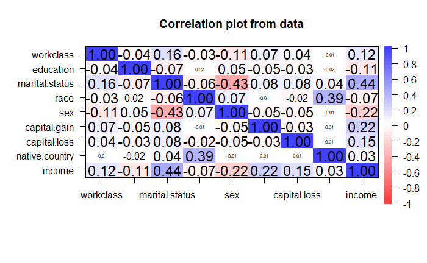

```
$corr
                  workclass   education marital.status        race          sex capital.gain capital.loss native.country      income
workclass       1.000000000 -0.04492495     0.15566702 -0.03186914 -0.108280739   0.06983781  0.039283110   -0.006033195  0.12111484
education      -0.044924952  1.00000000    -0.06764111  0.01798141  0.046092884  -0.05198748 -0.028582528   -0.018259545 -0.11341345
marital.status  0.155667020 -0.06764111     1.00000000 -0.06150696 -0.426348288   0.08261588  0.078614804    0.043890390  0.43614214
race           -0.031869145  0.01798141    -0.06150696  1.00000000  0.074496518  -0.01064992 -0.021685997    0.385139825 -0.06778734
sex            -0.108280739  0.04609288    -0.42634829  0.07449652  1.000000000  -0.04881405 -0.047011240   -0.009122571 -0.21669868
capital.gain    0.069837809 -0.05198748     0.08261588 -0.01064992 -0.048814054   1.00000000 -0.032229327    0.006320120  0.22119621
capital.loss    0.039283110 -0.02858253     0.07861480 -0.02168600 -0.047011240  -0.03222933  1.000000000    0.006116887  0.15005331
native.country -0.006033195 -0.01825954     0.04389039  0.38513983 -0.009122571   0.00632012  0.006116887    1.000000000  0.02871574
income          0.121114837 -0.11341345     0.43614214 -0.06778734 -0.216698681   0.22119621  0.150053308    0.028715745  1.00000000

$corrPos
```

| xName | yName | x | y | corr |
| --- | --- | --- | --- | --- |
| workclass | workclass | 1 | 9 | 1.000000000 |
| education | workclass | 2 | 9 | -0.044924952 |
| education | education | 2 | 8 | 1.000000000 |
| marital.status | workclass | 3 | 9 | 0.155667020 |
| marital.status | education | 3 | 8 | -0.067641113 |
| marital.status | marital.status | 3 | 7 | 1.000000000 |
| race | workclass | 4 | 9 | -0.031869145 |
| race | education | 4 | 8 | 0.017981410 |
| race | marital.status | 4 | 7 | -0.061506961 |
| race | race | 4 | 6 | 1.000000000 |

[output cut: 35 more lines]

```
$arg
$arg$type
[1] "upper"
```

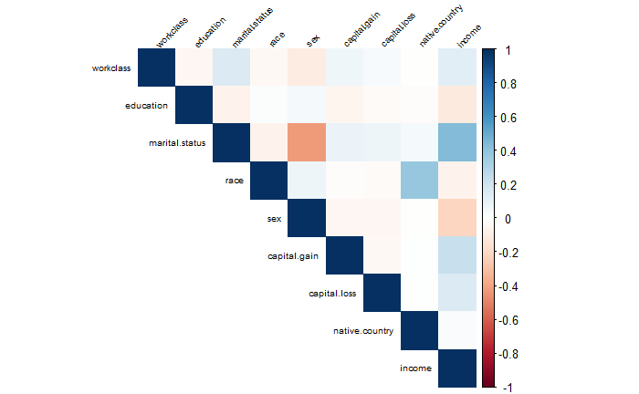

```r
correlation_plot(df1)
```

Both native country and race has very low corelation to income so it make no sense to include them in our analysis.

Placing our income column to last

```r
df1 <- df1[, c(setdiff(names(df1), "income"), "income")]
```

checking column names

```r
colnames(df1)
```

```
 [1] "age"               "workclass"         "fnlwgt"            "education"         "education.num"     "marital.status"    "race"              "sex"
 [9] "capital.gain"      "capital.loss"      "hours.per.week"    "native.country"    "Exec_managerial"   "Prof_specialty"    "Machine_op_inspct" "Tech_support"
[17] "Craft_repair"      "Transport_moving"  "Other_service"     "Adm_clerical"      "Sales"             "Farming_fishing"   "Protective_serv"   "Handlers_cleaners"
[25] "Armed_Forces"      "Priv_house_serv"   "income"
```

Plotting Age distribution

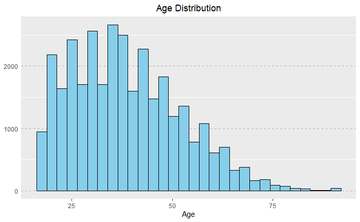

```r
ggplot(adult, aes(x = age)) +
  geom_histogram(fill = "skyblue", color = "black", bins = 30) +
  labs(title = "Age Distribution", x = "Age", y = "Count") +
  theme_cleveland() +
  theme(plot.title = element_text(hjust = 0.5))
```

Plotting Work class

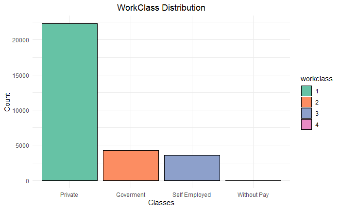

```r
df1$workclass = as.factor(df1$workclass)

custom_labels_w = c(
  "1" = "Private",
  "2" = "Goverment",
  "3" = "Self Employed",
  "4" = "Without Pay")

ggplot(df1, aes(x = workclass, fill = workclass, group = workclass)) +
  geom_bar(color = "black") +
  labs(title = "WorkClass Distribution", x = "Classes", y = "Count") +
  theme_minimal() +
  theme(plot.title = element_text(hjust = 0.5)) +
  scale_fill_brewer(palette = "Set2") +
  scale_x_discrete(labels = custom_labels_w)
```

Plotting Education Level

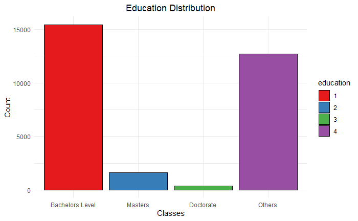

```r
df1$education = as.factor(df1$education)

custom_labels_e = c(
  "1" = "Bachelors Level",
  "2" = "Masters",
  "3" = "Doctorate",
  "4" = "Others")

ggplot(df1, aes(x = education, fill = education, group = education)) +
  geom_bar(color = "black") +
  labs(title = "Education Distribution", x = "Classes", y = "Count") +
  theme_minimal() +
  theme(plot.title = element_text(hjust = 0.5)) +
  scale_fill_brewer(palette = "Set1")+
  scale_x_discrete(labels = custom_labels_e)
```

```r
NA
```

Plotting Marital Status

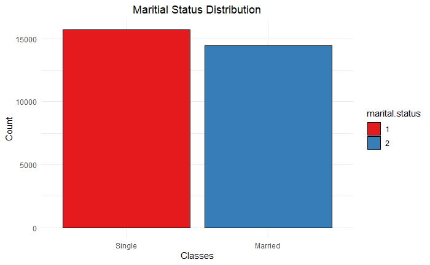

```r
df1$marital.status = as.factor(df1$marital.status)

custom_labels_m = c(
  "1" = "Single",
  "2" = "Married")

ggplot(df1, aes(x = marital.status, fill = marital.status, group = marital.status)) +
  geom_bar(color = "black") +
  labs(title = "Maritial Status Distribution", x = "Classes", y = "Count") +
  theme_minimal() +
  theme(plot.title = element_text(hjust = 0.5)) +
  scale_fill_brewer(palette = "Set1") +
   scale_x_discrete(labels = custom_labels_m)
```

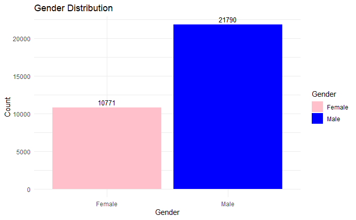

```r
# Convert the 'sex' column to a factor (if not already)
adult$sex <- as.factor(adult$sex)

# Create a data frame for plotting
gender_df <- as.data.frame(table(adult$sex))
names(gender_df) <- c("Gender", "Count")

# Create a bar graph
ggplot(gender_df, aes(x = Gender, y = Count, fill = Gender)) +
  geom_bar(stat = "identity", position = position_dodge()) +
  scale_fill_manual(values = c("pink", "blue")) +
  labs(title = "Gender Distribution", x = "Gender", y = "Count") +
  geom_text(aes(label = Count), vjust = -0.5, position = position_dodge(0.9), size = 3.5) +
  theme_minimal()
```

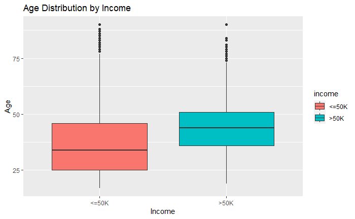

```r
ggplot(adult, aes(x = income, y = age, fill = income)) +
  geom_boxplot() +
  labs(title = "Age Distribution by Income", x = "Income", y = "Age")
```

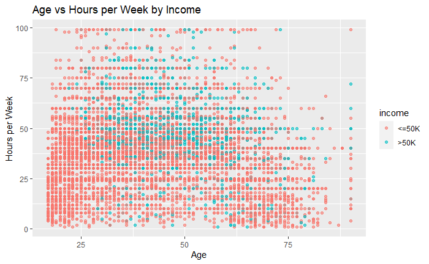

```r
ggplot(adult, aes(x = age, y = hours.per.week, color = income)) +
  geom_point(alpha = 0.6) +
  labs(title = "Age vs Hours per Week by Income", x = "Age", y = "Hours per Week")
```

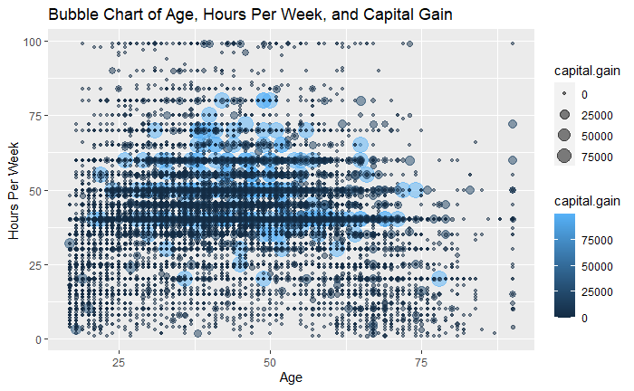

```r
ggplot(adult, aes(x = age, y = hours.per.week, size = capital.gain, color = capital.gain)) +
  geom_point(alpha = 0.5) +
  labs(title = "Bubble Chart of Age, Hours Per Week, and Capital Gain", x = "Age", y = "Hours Per Week")
```

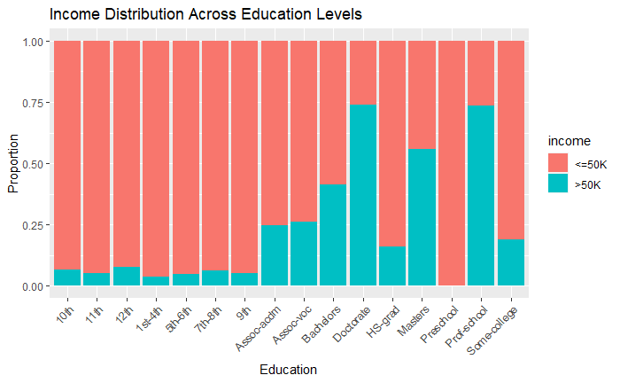

```r
ggplot(adult, aes(x = education, fill = income)) +
  geom_bar(position = "fill") +
  labs(title = "Income Distribution Across Education Levels", x = "Education", y = "Proportion") +
  theme(axis.text.x = element_text(angle = 45, hjust = 1))
```

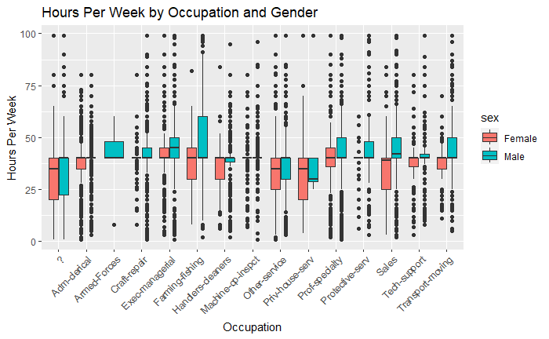

```r
ggplot(adult, aes(x = occupation, y = hours.per.week, fill = sex)) +
  geom_boxplot() +
  labs(title = "Hours Per Week by Occupation and Gender", x = "Occupation", y = "Hours Per Week") +
  theme(axis.text.x = element_text(angle = 45, hjust = 1))
```

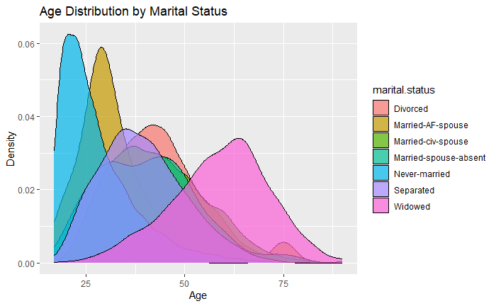

```r
ggplot(adult, aes(x = age, fill = marital.status)) +
  geom_density(alpha = 0.7) +
  labs(title = "Age Distribution by Marital Status", x = "Age", y = "Density")
```

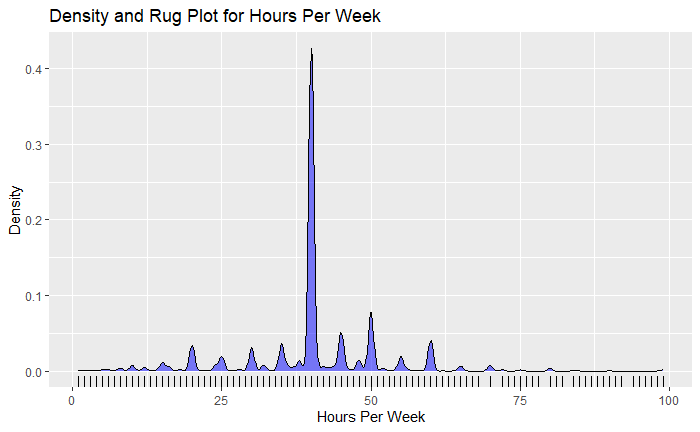

```r
ggplot(adult, aes(x = hours.per.week)) +
  geom_density(fill = "blue", alpha = 0.5) +
  geom_rug() +
  labs(title = "Density and Rug Plot for Hours Per Week", x = "Hours Per Week", y = "Density")
```

[figure not shown]

```r
marital_income_table <- table(adult$relationship, adult$income)
mosaicplot(marital_income_table, shade = TRUE,
       main = "Mosaic Plot of Marital Status and Income",
       xlab = "Income", ylab = "Marital Status")
```

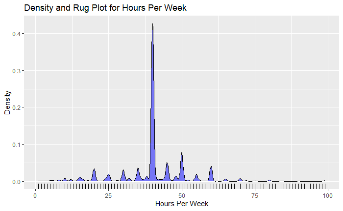

```r
ggplot(adult, aes(x = hours.per.week)) +
  geom_density(fill = "blue", alpha = 0.5) +
  geom_rug() +
  labs(title = "Density and Rug Plot for Hours Per Week", x = "Hours Per Week", y = "Density")
```

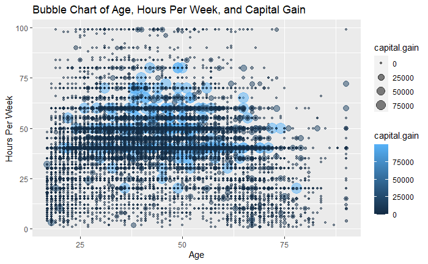

```r
ggplot(adult, aes(x = age, y = hours.per.week, size = capital.gain, color = capital.gain)) +
  geom_point(alpha = 0.5) +
  labs(title = "Bubble Chart of Age, Hours Per Week, and Capital Gain", x = "Age", y = "Hours Per Week")
```

##Lets start building models

Lets first convert numeric data to factor.

```r
df1$workclass = as.factor(df1$workclass)
df1$education = as.factor(df1$education)
df1$marital.status = as.factor(df1$marital.status)
df1$income= as.factor(df1$income)
df1 = na.omit(df1)
```

As we can see every possible numerical data is converted into categories.

```r
summary(df1)
```

```
 age      workclass fnlwgt   education education.num marital.status      race            sex         capital.gain    capital.loss     hours.per.week native.country
 1:7667   1:21943   1:7447   1:15415   1:13205       1:15349        Min.   :1.000   Min.   :1.000   Min.   :    0   Min.   :   0.00   1:20594        Min.   :1.000
 2:7399   2: 4266   2:7440   2: 1627   2: 6674       2:14432        1st Qu.:1.000   1st Qu.:1.000   1st Qu.:    0   1st Qu.:   0.00   2: 2352        1st Qu.:1.000
 3:7390   3: 3558   3:7451   3:  374   3: 7359                      Median :1.000   Median :1.000   Median :    0   Median :   0.00   3: 6835        Median :1.000
 4:7325   4:   14   4:7443   4:12365   4: 2543                      Mean   :1.195   Mean   :1.323   Mean   : 1104   Mean   :  88.77                  Mean   :1.058
                                                                    3rd Qu.:1.000   3rd Qu.:2.000   3rd Qu.:    0   3rd Qu.:   0.00                  3rd Qu.:1.000
                                                                    Max.   :4.000   Max.   :2.000   Max.   :99999   Max.   :4356.00                  Max.   :3.000
 Exec_managerial Prof_specialty Machine_op_inspct Tech_support  Craft_repair  Transport_moving Other_service Adm_clerical    Sales       Farming_fishing
 FALSE:25791     FALSE:25755    FALSE:27831       FALSE:28870   FALSE:25770   FALSE:28212      FALSE:26713   FALSE:26086   FALSE:26283   FALSE:28810
 TRUE : 3990     TRUE : 4026    TRUE : 1950       TRUE :  911   TRUE : 4011   TRUE : 1569      TRUE : 3068   TRUE : 3695   TRUE : 3498   TRUE :  971




 Protective_serv Handlers_cleaners Armed_Forces  Priv_house_serv income
 FALSE:29140     FALSE:28472       FALSE:29772   FALSE:29648     1:22274
 TRUE :  641     TRUE : 1309       TRUE :    9   TRUE :  133     2: 7507
```

Creating a loop for each model to run multiple times with random trainnig and testing dataset and getting best accuracy possible.

```r
# Initialize an empty data frame to store results
results_df1 <- data.frame(
  Dataset_Number = integer(),
  Model = character(),
  Train_Accuracy = numeric(),
  Test_Accuracy = numeric()
)

# Define a list of models
models <- list(
  Decision_Tree = rpart,
  Random_Forest = randomForest,
  Support_Vector = svm,
  Naive_Bayes = naiveBayes
)

# Create a list to store datasets
dataset_list <- list()

# Loop through models
for (model_name in names(models)) {
  model <- models[[model_name]]

  for (i in 1:2) {
    # Split the data
    data = split_show(df1, 0.6)
    df_train = data[[2]]
    df_test = data[[3]]

    # Store the dataset in the dataset_list
    dataset_list[[i]] <- list(df_train = df_train, df_test = df_test)

    # Fit the model
    if (model_name == "Random_Forest") {
      model <- randomForest(income ~ ., data = df_train, ntree = 5)
    } else if (model_name == "Support_Vector") {
      model <- svm(income ~ ., data = df_train, kernel = "linear")
    } else if (model_name == "Naive_Bayes") {
      model <- naiveBayes(income ~ ., data = df_train)
    } else {
      model <- rpart(income ~ ., data = df_train, method = 'class', cp = -1)
    }

    # Make predictions on the train and test data to compare
    y_pred_train <- predict(model, newdata = df_train, type = 'class')
    y_pred_test <- predict(model, newdata = df_test, type = 'class')

    # Calculate train and test accuracy
    train_accuracy <- sum(y_pred_train == df_train$income) / nrow(df_train)
    test_accuracy <- sum(y_pred_test == df_test$income) / nrow(df_test)

    # Add results to results_df
    results_df1 <- rbind(results_df1, data.frame(
      Dataset_Number = i,
      Model = model_name,
      Train_Accuracy = train_accuracy,
      Test_Accuracy = test_accuracy
    ))
  }
}
# Display the results
#print(results_df1)
```

Running different loop for logistic Regression because we can’t do it in upper loop.

Because other algorithms use “Class” type for prediction and Logistic Regression uses Response type. Its difficult to add logistic in upper loop.

```r
# Initialize an empty data frame to store results
results_df_logistic <- data.frame(
  Dataset_Number = integer(),
  Train_Accuracy = numeric(),
  Test_Accuracy = numeric()
)

# Create a list to store datasets
dataset_list_logistic <- list()

#Initializing loop
for (i in 1:2) {
  # Split the data
  data = split_show(df1, 0.6)
  df_train = data[[2]]
  df_test = data[[3]]

  # Store the dataset in the dataset_list
  dataset_list_logistic[[i]] <- list(df_train = df_train, df_test = df_test)

  # Fit the logistic regression model
  logistic_model <- glm(income ~ ., family = binomial, data = df_train)
  y_pred_train <- predict(logistic_model, newdata = df_train, type = "response")
  y_pred_test <- predict(logistic_model, newdata = df_test, type = "response")

  threshold <- 0.5
  y_pred_train_class <- ifelse(y_pred_train >= threshold, 2, 1)
  y_pred_test_class <- ifelse(y_pred_test >= threshold, 2, 1)

  # Calculate train and test accuracy
  train_accuracy <- sum(y_pred_train_class == df_train$income) / nrow(df_train)
  test_accuracy <- sum(y_pred_test_class == df_test$income) / nrow(df_test)

  # Add results to results_df_logistic
  results_df_logistic <- rbind(results_df_logistic, data.frame(
    Dataset_Number = i,
    Model = "Logistic_Regression",
    Train_Accuracy = train_accuracy,
    Test_Accuracy = test_accuracy
  ))
}
# Display the results
#print(results_df_logistic)
```

Adding logistic Regression to other models and creating one final data frame of train and test accuracy.

```r
results_df_final1 <- rbind(results_df1,results_df_logistic)
```

```r
#Display the results
results_df_final1
```

| Dataset_Number | Model | Train_Accuracy | Test_Accuracy |
| --- | --- | --- | --- |
| 1 | Decision_Tree | 0.8730692 | 0.8401746 |
| 2 | Decision_Tree | 0.8743004 | 0.8348863 |
| 1 | Random_Forest | 0.8807925 | 0.8462184 |
| 2 | Random_Forest | 0.8844303 | 0.8450432 |
| 1 | Support_Vector | 0.8468211 | 0.8412658 |
| 2 | Support_Vector | 0.8469890 | 0.8446235 |
| 1 | Naive_Bayes | 0.8026080 | 0.8018131 |
| 2 | Naive_Bayes | 0.8056861 | 0.8011416 |
| 1 | Logistic_Regression | 0.8439669 | 0.8452111 |
| 2 | Logistic_Regression | 0.8432393 | 0.8454629 |

```r
# Extract the row with the maximum test accuracy
results_df_final1[which.max(results_df_final1$Test_Accuracy), ]
```

|  | Dataset_Number | Model | Train_Accuracy | Test_Accuracy |
| --- | --- | --- | --- | --- |
| 3 | 1 | Random_Forest | 0.8807925 | 0.8462184 |

```r
NA
```

Plotting Max test accuracy from each model to compare it with other models.

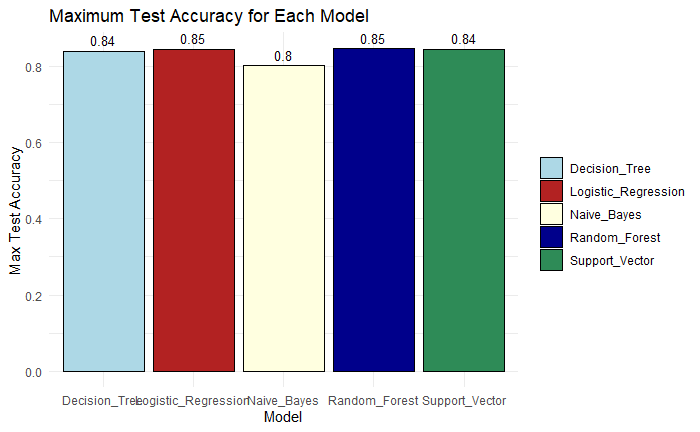

```r
max_test_accuracy <- aggregate(Test_Accuracy ~ Model, data = results_df_final1, FUN = max)

bar_colors <- c("lightblue", "firebrick", "lightyellow", "darkblue", "seagreen")

# Create a bar plot with different colors for each bar
ggplot(data = max_test_accuracy, aes(x = Model, y = Test_Accuracy, fill = Model)) +
  geom_bar(stat = "identity", color = "black") +  # Set the outline color to black
  scale_fill_manual(values = bar_colors) +  # Assign custom colors to bars
  geom_text(aes(label = round(Test_Accuracy, 2)), vjust = -0.5, size = 3.5) +  # Add text labels
  labs(title = "Maximum Test Accuracy for Each Model",
       x = "Model",
       y = "Max Test Accuracy") +
  theme_minimal() +
  theme(legend.title = element_blank())
```

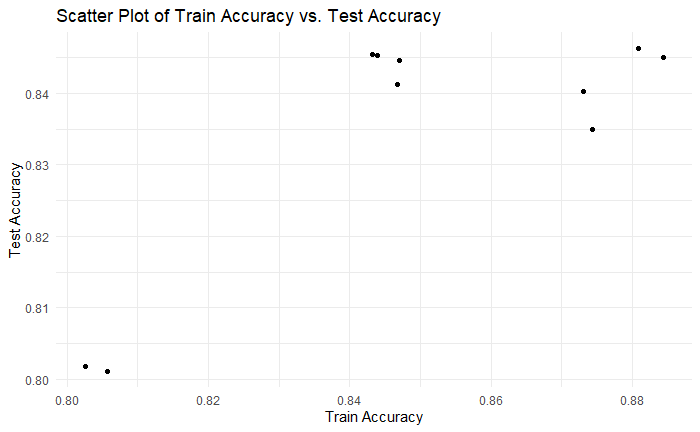

```r
ggplot(data = results_df_final1, aes(x = Train_Accuracy, y = Test_Accuracy)) +
  geom_point() +
  labs(title = "Scatter Plot of Train Accuracy vs. Test Accuracy",
       x = "Train Accuracy",
       y = "Test Accuracy") +
  theme_minimal()
```

```r
df1 = na.omit(df1)
```

```r
df2 = df1
```

```r
 fit=randomForest(factor(income)~., data=df1)
```

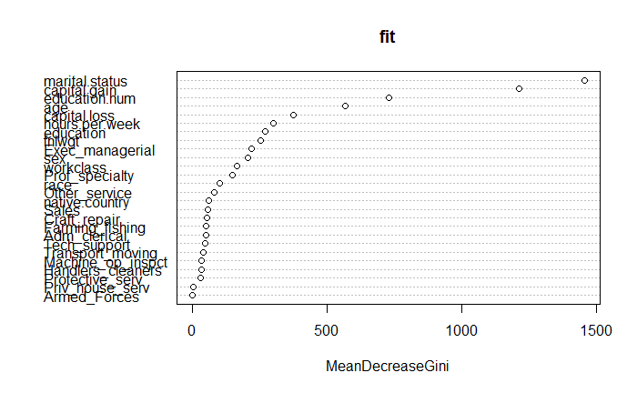

```r
varImpPlot(fit,type=2)
```

```r
#df2$Exec_managerial = NULL
#df2$Prof_specialty= NULL
df2$Machine_op_inspct= NULL
df2$Transport_moving= NULL
df2$Craft_repair= NULL
df2$Handlers_cleaners= NULL
df2$Farming_fishing= NULL
df2$Adm_clerical= NULL
df2$Other_service= NULL
df2$Adm_clerical = NULL
df2$Sales =NULL
df2$Farming_fishing = NULL
df2$Protective_serv = NULL
df2$Handlers_cleaners = NULL
df2$Armed_Forces = NULL
df2$Priv_house_serv = NULL
df2$Tech_support = NULL
df2$fnlwgt = NULL
#df2$education.num = NULL
df2$race = NULL
df2$native.country = NULL
```

```r
knn_class_st = train(income ~ ., data = df_train, method = "knn",tuneGrid = data.frame(k = seq(10)))
```

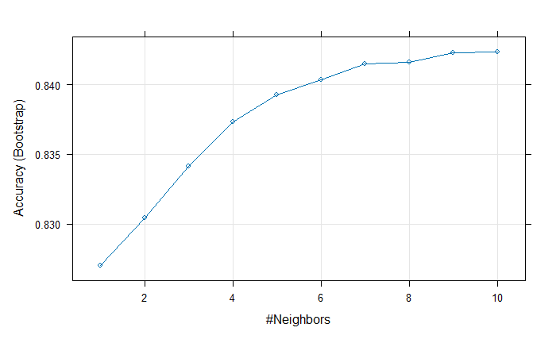

```r
plot(knn_class_st)
```

```r
xgbTree_classifier = train(income ~ ., data = df_train,method = 'xgbTree',verbose = 1)
```

[output not shown]

[output cut: 1745 more lines]

[output not shown]

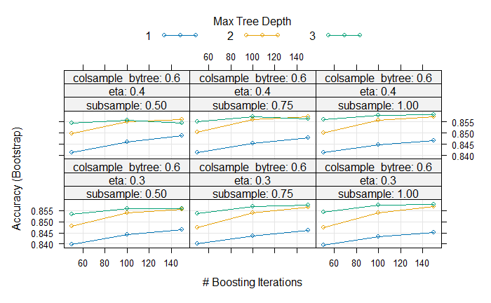

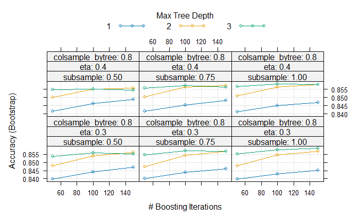

```r
plot(xgbTree_classifier)
```

```r
df2 = na.omit(df2)

df2$income = as.factor(df2$income)
```

```r
results_df2 <- data.frame(
  Dataset_Number = integer(),
  Model = character(),
  Train_Accuracy = numeric(),
  Test_Accuracy = numeric()
)

# Define a list of models
models <- list(
  Decision_Tree = rpart,
  Random_Forest = randomForest,
  Support_Vector = svm,
  Naive_Bayes = naiveBayes
)

# Create a list to store datasets
dataset_list2 <- list()

# Loop through models
for (model_name in names(models)) {
  model <- models[[model_name]]

  for (i in 1:2) {
    # Split the data
    data = split_show(df2, 0.6)
    df_train = data[[2]]
    df_test = data[[3]]

    # Store the dataset in the dataset_list
    dataset_list2[[i]] <- list(df_train = df_train, df_test = df_test)

    # Fit the model
    if (model_name == "Random_Forest") {
      model <- randomForest(income ~ ., data = df_train, ntree = 5)
    } else if (model_name == "Support_Vector") {
      model <- svm(income ~ ., data = df_train, kernel = "linear")
    } else if (model_name == "Naive_Bayes") {
      model <- naiveBayes(income ~ ., data = df_train)
    }else {
      model <- rpart(income ~ ., data = df_train, method = 'class', cp = -1)
    }

    # Make predictions on the test data
    y_pred_train <- predict(model, newdata = df_train, type = 'class')
    y_pred_test <- predict(model, newdata = df_test, type = 'class')

    # Calculate train and test accuracy
    train_accuracy <- sum(y_pred_train == df_train$income) / nrow(df_train)
    test_accuracy <- sum(y_pred_test == df_test$income) / nrow(df_test)

    # Add results to results_df
    results_df2 <- rbind(results_df2, data.frame(
      Dataset_Number = i,
      Model = model_name,
      Train_Accuracy = train_accuracy,
      Test_Accuracy = test_accuracy
    ))
  }
}
```

```r
results_df2_extra <- data.frame(
  Dataset_Number = integer(),
  Model = character(),
  Train_Accuracy = numeric(),
  Test_Accuracy = numeric()
)

# Define a list of models
models <- list(
  XGBtree = train,
  KNN = train
)

# Create a list to store datasets
dataset_list2_extra <- list()

# Loop through models
for (model_name in names(models)) {
  model <- models[[model_name]]

  for (i in 1:2) {
    # Split the data
    data = split_show(df2, 0.6)
    df_train = data[[2]]
    df_test = data[[3]]

    # Store the dataset in the dataset_list
    dataset_list2_extra[[i]] <- list(df_train = df_train, df_test = df_test)
     if (model_name == "XGBtree"){
      model = train(income ~ ., data = df_train,method = 'xgbTree',verbose = 1)
    } else {
      model = train(income ~ ., data = df_train, method = "knn")#tuneGrid = data.frame(k = seq(10)))
    }

    y_pred_train <- predict(model, newdata = df_train, type = 'raw')
    y_pred_test <- predict(model, newdata = df_test, type = 'raw')

    # Calculate train and test accuracy
    train_accuracy <- sum(y_pred_train == df_train$income) / nrow(df_train)
    test_accuracy <- sum(y_pred_test == df_test$income) / nrow(df_test)

    # Add results to results_df
    results_df2_extra <- rbind(results_df2_extra, data.frame(
      Dataset_Number = i,
      Model = model_name,
      Train_Accuracy = train_accuracy,
      Test_Accuracy = test_accuracy
    ))
  }
}
```

[output not shown]

[output cut: 3545 more lines]

[output not shown]

```r
results_df_logistic2 <- data.frame(
  Dataset_Number = integer(),
  Train_Accuracy = numeric(),
  Test_Accuracy = numeric()
)

# Create a list to store datasets
dataset_list_logistic2 <- list()

for (i in 1:2) {
  # Split the data
  data = split_show(df2, 0.6)
  df_train = data[[2]]
  df_test = data[[3]]

  # Store the dataset in the dataset_list
  dataset_list_logistic2[[i]] <- list(df_train = df_train, df_test = df_test)

  # Fit the logistic regression model
  logistic_model <- glm(income ~ ., family = binomial, data = df_train)
  y_pred_train <- predict(logistic_model, newdata = df_train, type = "response")
  y_pred_test <- predict(logistic_model, newdata = df_test, type = "response")

  threshold <- 0.5
  y_pred_train_class <- ifelse(y_pred_train >= threshold, 2, 1)
  y_pred_test_class <- ifelse(y_pred_test >= threshold, 2, 1)

  # Calculate train and test accuracy
  train_accuracy <- sum(y_pred_train_class == df_train$income) / nrow(df_train)
  test_accuracy <- sum(y_pred_test_class == df_test$income) / nrow(df_test)

  # Add results to results_df_logistic
  results_df_logistic2 <- rbind(results_df_logistic2, data.frame(
    Dataset_Number = i,
    Model = "Logistic_Regression",
    Train_Accuracy = train_accuracy,
    Test_Accuracy = test_accuracy
  ))
}
```

```r
results_df_final2 <- rbind(results_df2,results_df_logistic2,results_df2_extra)
results_df_final2[which.max(results_df_final2$Test_Accuracy), ]
```

|  | Dataset_Number | Model | Train_Accuracy | Test_Accuracy |
| --- | --- | --- | --- | --- |
| 11 | 1 | XGBtree | 0.8608126 | 0.8614958 |

```r
results_df_final2
```

| Dataset_Number | Model | Train_Accuracy | Test_Accuracy |
| --- | --- | --- | --- |
| 1 | Decision_Tree | 0.8613163 | 0.8492403 |
| 2 | Decision_Tree | 0.8619879 | 0.8448753 |
| 1 | Random_Forest | 0.8648422 | 0.8473936 |
| 2 | Random_Forest | 0.8682001 | 0.8434483 |
| 1 | Support_Vector | 0.8405529 | 0.8379921 |
| 2 | Support_Vector | 0.8401612 | 0.8399228 |
| 1 | Naive_Bayes | 0.7974032 | 0.7968606 |
| 2 | Naive_Bayes | 0.7997537 | 0.7966087 |
| 1 | Logistic_Regression | 0.8411686 | 0.8383279 |
| 2 | Logistic_Regression | 0.8427916 | 0.8377403 |

[output cut: 4 more lines]

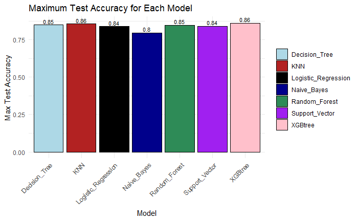

```r
max_test_accuracy <- aggregate(Test_Accuracy ~ Model, data = results_df_final2, FUN = max)

bar_colors <- c("lightblue", "firebrick", "black", "darkblue", "seagreen","purple","pink")

# Create a bar plot with different colors for each bar
ggplot(data = max_test_accuracy, aes(x = Model, y = Test_Accuracy, fill = Model)) +
  geom_bar(stat = "identity", color = "black") +  # Set the outline color to black
  scale_fill_manual(values = bar_colors) +  # Assign custom colors to bars
  geom_text(aes(label = round(Test_Accuracy, 2)), vjust = -0.3, size = 3) +  # Add text labels
  labs(title = "Maximum Test Accuracy for Each Model",
       x = "Model",
       y = "Max Test Accuracy") +
  theme_minimal() +
  theme(legend.title = element_blank(),
        axis.text.x = element_text(angle = 45, hjust = 1))
```

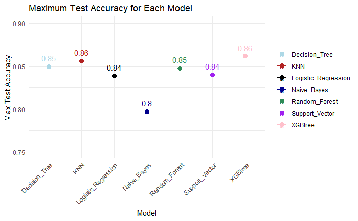

```r
# Create a line chart with different colors for each line
ggplot(data = max_test_accuracy, aes(x = Model, y = Test_Accuracy, group = Model, color = Model)) +
  geom_line() +  # Use geom_line to create a line chart
  geom_point(size = 3) +  # Add points for data points
  scale_color_manual(values = bar_colors) +  # Assign custom colors to lines
  geom_text(aes(label = round(Test_Accuracy, 2)), vjust = -0.9, size = 4) +  # Add text labels
  labs(title = "Maximum Test Accuracy for Each Model",
       x = "Model",
       y = "Max Test Accuracy") +
  theme_minimal() +
  theme(legend.title = element_blank(),
        axis.text.x = element_text(angle = 45, hjust = 1)) +
  ylim(0.75, 0.90)
```

```r
library(pROC)

df_test$income = as.numeric(df_test$income)
roc_obj = roc(df_test$income, y_pred_test)
```

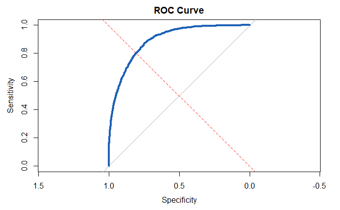

```r
plot(roc_obj, main="ROC Curve", col="#1c61b6", lwd=4)
abline(a=0, b=1, lty=2, col="red")
```

```r
auc(roc_obj)
```

```
Area under the curve: 0.8927
```

```r
# Replace "Your_Test_Data" with your actual test data
predictions <- predict(tree_model, newdata = df_test)
```

```r
tree_model = rpart(income ~., data = df_train,
  method = 'class', #method for classification trees.
  parms = list(split = 'information'),
  minsplit = 2,
  minbucket = 1, #Run model without the last two to get a full tree.
  maxdepth = 10,
  cp = -1)
```

```r
y_pred_train = predict(tree_model,newdata=df_train,type = 'class' )
y_pred_test = predict(tree_model,newdata=df_test, type = 'class')

cat('TRAIN RESULTS \n\n')
```

```
TRAIN RESULTS
```

```r
df_train_results = data.frame(y_pred_train,df_train$income)
confusionMatrix(table(df_train_results))
```

```
Confusion Matrix and Statistics

            df_train.income
y_pred_train     1     2
           1 12709  1779
           2   655  2725

               Accuracy : 0.8638
                 95% CI : (0.8587, 0.8688)
    No Information Rate : 0.7479
    P-Value [Acc > NIR] : < 0.00000000000000022

                  Kappa : 0.6061

 Mcnemar's Test P-Value : < 0.00000000000000022

            Sensitivity : 0.9510
            Specificity : 0.6050
         Pos Pred Value : 0.8772
         Neg Pred Value : 0.8062
             Prevalence : 0.7479
         Detection Rate : 0.7113
   Detection Prevalence : 0.8108
      Balanced Accuracy : 0.7780

       'Positive' Class : 1
```

```r
cat('\n\nTEST RESULTS\n\n')
```

```
TEST RESULTS
```

```r
df_test_results = data.frame(y_pred_test,df_test$income)
confusionMatrix(table(df_test_results))
```

```
Confusion Matrix and Statistics

           df_test.income
y_pred_test    1    2
          1 8377 1282
          2  533 1721

               Accuracy : 0.8476
                 95% CI : (0.8411, 0.8541)
    No Information Rate : 0.7479
    P-Value [Acc > NIR] : < 0.00000000000000022

                  Kappa : 0.5595

 Mcnemar's Test P-Value : < 0.00000000000000022

            Sensitivity : 0.9402
            Specificity : 0.5731
         Pos Pred Value : 0.8673
         Neg Pred Value : 0.7635
             Prevalence : 0.7479
         Detection Rate : 0.7032
   Detection Prevalence : 0.8108
      Balanced Accuracy : 0.7566

       'Positive' Class : 1
```

```r
library(randomForest)
```

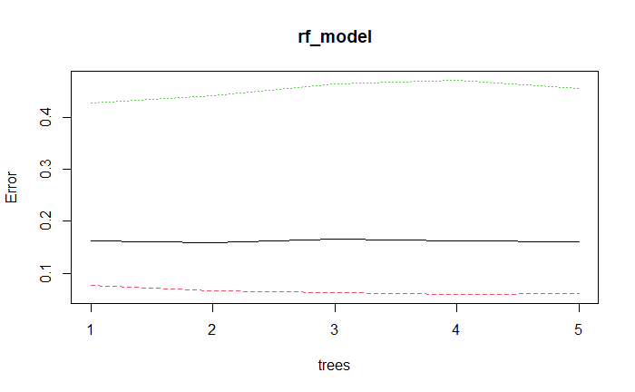

```r
plot(rf_model)
```

```r
rf_model <- randomForest(income ~ ., data = df_train, ntree = 5)
```

```r
y_pred_train = predict(rf_model,newdata=df_train,type = 'class' )
y_pred_test = predict(rf_model,newdata=df_test, type = 'class')

cat('TRAIN RESULTS \n\n')
```

```
TRAIN RESULTS
```

```r
df_train_results = data.frame(y_pred_train,df_train$income)
confusionMatrix(table(df_train_results))
```

```
Confusion Matrix and Statistics

            df_train.income
y_pred_train     1     2
           1 12804  1839
           2   560  2665

               Accuracy : 0.8657
                 95% CI : (0.8607, 0.8707)
    No Information Rate : 0.7479
    P-Value [Acc > NIR] : < 0.00000000000000022

                  Kappa : 0.6069

 Mcnemar's Test P-Value : < 0.00000000000000022

            Sensitivity : 0.9581
            Specificity : 0.5917
         Pos Pred Value : 0.8744
         Neg Pred Value : 0.8264
             Prevalence : 0.7479
         Detection Rate : 0.7166
   Detection Prevalence : 0.8195
      Balanced Accuracy : 0.7749

       'Positive' Class : 1
```

```r
cat('\n\nTEST RESULTS\n\n')
```

```
TEST RESULTS
```

```r
df_test_results = data.frame(y_pred_test,df_test$income)
confusionMatrix(table(df_test_results))
```

```
Confusion Matrix and Statistics

           df_test.income
y_pred_test    1    2
          1 8429 1375
          2  481 1628

               Accuracy : 0.8442
                 95% CI : (0.8376, 0.8507)
    No Information Rate : 0.7479
    P-Value [Acc > NIR] : < 0.00000000000000022

                  Kappa : 0.5416

 Mcnemar's Test P-Value : < 0.00000000000000022

            Sensitivity : 0.9460
            Specificity : 0.5421
         Pos Pred Value : 0.8598
         Neg Pred Value : 0.7719
             Prevalence : 0.7479
         Detection Rate : 0.7075
   Detection Prevalence : 0.8230
      Balanced Accuracy : 0.7441

       'Positive' Class : 1
```

```r
svm_model <- svm(income ~ ., data = df_train, kernel = "linear")

nb_model <- naiveBayes(income ~ ., data = df_train)
```

```r
y_pred_train = predict(svm_model,newdata=df_train,type = 'class' )
y_pred_test = predict(svm_model,newdata=df_test, type = 'class')

df_test_results = data.frame(y_pred_test,df_test$income)
confusionMatrix(table(df_test_results))
```

```
Confusion Matrix and Statistics

           df_test.income
y_pred_test    1    2
          1 8322 1346
          2  588 1657

               Accuracy : 0.8377
                 95% CI : (0.8309, 0.8442)
    No Information Rate : 0.7479
    P-Value [Acc > NIR] : < 0.00000000000000022

                  Kappa : 0.5301

 Mcnemar's Test P-Value : < 0.00000000000000022

            Sensitivity : 0.9340
            Specificity : 0.5518
         Pos Pred Value : 0.8608
         Neg Pred Value : 0.7381
             Prevalence : 0.7479
         Detection Rate : 0.6986
   Detection Prevalence : 0.8116
      Balanced Accuracy : 0.7429

       'Positive' Class : 1
```

```r
svm_pred = prediction(y_pred_test, df_test$income)
```

[output not shown]

```r
y_pred_train = predict(nb_model,newdata=df_train,type = 'class' )
y_pred_test = predict(nb_model,newdata=df_test, type = 'class')

df_test_results = data.frame(y_pred_test,df_test$income)
confusionMatrix(table(df_test_results))
```

```
Confusion Matrix and Statistics

           df_test.income
y_pred_test    1    2
          1 8421 1900
          2  489 1103

               Accuracy : 0.7995
                 95% CI : (0.7922, 0.8066)
    No Information Rate : 0.7479
    P-Value [Acc > NIR] : < 0.00000000000000022

                  Kappa : 0.3701

 Mcnemar's Test P-Value : < 0.00000000000000022

            Sensitivity : 0.9451
            Specificity : 0.3673
         Pos Pred Value : 0.8159
         Neg Pred Value : 0.6928
             Prevalence : 0.7479
         Detection Rate : 0.7069
   Detection Prevalence : 0.8664
      Balanced Accuracy : 0.6562

       'Positive' Class : 1
```

```r
logistic_model <- glm(income ~ ., family = binomial, data = df_train)
```

```r
y_pred_train = predict(logistic_model,newdata=df_train,type = 'response' )
y_pred_test = predict(logistic_model,newdata=df_test, type = 'response')
```

```r
library(forestplot)
odds_ratios <- exp(coef(logistic_model))
forestplot(odds_ratios, main = "Odds Ratios", is.summary = "response")
```

[output not shown]

```r
library(effects)
effect_plot <- effect('income', logistic_model)
```

[output not shown]

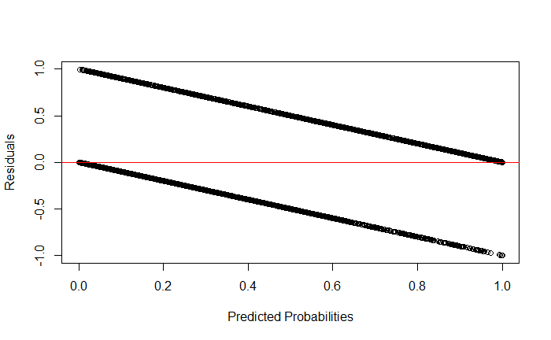

```r
residuals <- residuals(logistic_model, type = "response")
predicted_probs <- predict(logistic_model, type = "response")
plot(predicted_probs, residuals, ylab = "Residuals", xlab = "Predicted Probabilities")
abline(h = 0, col = "red")
```

```r
xgb_model = train(income ~ ., data = df_train,method = 'xgbTree',verbose = 1)
```

[output not shown]

[output cut: 1745 more lines]

[output not shown]

```r
knn_model = train(income ~ ., data = df_train, method = "knn")
```

```r
# Create an explainer for the XGBoost model
explainer <- createExplainer(xgb_model)
```

[output not shown]

```r
y_pred_train = predict(xgb_model,newdata=df_train,type = 'raw' )
y_pred_test = predict(xgb_model,newdata=df_test, type = 'raw')


df_test_results = data.frame(y_pred_test,df_test$income)
confusionMatrix(table(df_test_results))
```

```
Confusion Matrix and Statistics

           df_test.income
y_pred_test    1    2
          1 8382 1155
          2  528 1848

               Accuracy : 0.8587
                 95% CI : (0.8523, 0.8649)
    No Information Rate : 0.7479
    P-Value [Acc > NIR] : < 0.00000000000000022

                  Kappa : 0.5975

 Mcnemar's Test P-Value : < 0.00000000000000022

            Sensitivity : 0.9407
            Specificity : 0.6154
         Pos Pred Value : 0.8789
         Neg Pred Value : 0.7778
             Prevalence : 0.7479
         Detection Rate : 0.7036
   Detection Prevalence : 0.8006
      Balanced Accuracy : 0.7781

       'Positive' Class : 1
```

```r
y_pred_train = predict(knn_model,newdata=df_train,type = 'raw' )
y_pred_test = predict(knn_model,newdata=df_test, type = 'raw')


df_test_results = data.frame(y_pred_test,df_test$income)
confusionMatrix(table(df_test_results))
```

```
Confusion Matrix and Statistics

           df_test.income
y_pred_test    1    2
          1 8394 1257
          2  516 1746

               Accuracy : 0.8512
                 95% CI : (0.8447, 0.8575)
    No Information Rate : 0.7479
    P-Value [Acc > NIR] : < 0.00000000000000022

                  Kappa : 0.5701

 Mcnemar's Test P-Value : < 0.00000000000000022

            Sensitivity : 0.9421
            Specificity : 0.5814
         Pos Pred Value : 0.8698
         Neg Pred Value : 0.7719
             Prevalence : 0.7479
         Detection Rate : 0.7046
   Detection Prevalence : 0.8101
      Balanced Accuracy : 0.7618

       'Positive' Class : 1
```